# Task 4: Functions Toolkit

Author

Artem

Published

04/11/2025

Question description Atomic Types

Create the following variables related to your chosen object:

4 numeric values (e.g., population, temperature, size, rating) 3 integer values (e.g., number of moons, buildings, inhabitants) 2 logical values (e.g., has_water, is_inhabited) 3 character values (e.g., name, region, category)

My object is Kiev city

```r
# code for solving task
#numeric


temperature <- 1.15
population <- 2.904346
size <- 8.398470
cars <- 9.242323

#integer


skyscrapers <- 1222
inhabitants <- 2483789
shopingsmalls <- 78

#logical


river <- TRUE
ocean <- FALSE


#character


name <- "OleksandrUsyk"
region <- "Kiev"
name <- "Shevchenko"






## Question 1.2.Vectors


# 1. Numeric vector (mix of numeric and integer values)
numeric_vector <- c(temperature, population, size, cars)
numeric_vector
```

```
[1] 1.150000 2.904346 8.398470 9.242323
```

```r
# 2. Sequence vector from 25 to 100 with a step of 5
sequence_vector <- seq(from = 25, to = 100, by = 5)
sequence_vector
```

```
 [1]  25  30  35  40  45  50  55  60  65  70  75  80  85  90  95 100
```

```r
# 3. Logical vector of length 10 with random TRUE/FALSE values
set.seed(7)  # set seed for reproducibility
logical_vector <- sample(c(TRUE, FALSE), size = 10, replace = TRUE)
logical_vector
```

```
 [1] FALSE  TRUE  TRUE FALSE  TRUE FALSE  TRUE FALSE FALSE FALSE
```

```r
## Question 1.3.Matrix


# Create a 3x3 matrix with random integers between -50 and 50
set.seed(10)  # for reproducibility
env_matrix <- matrix(sample(-50:50, 9 ), nrow = 3, ncol = 3)

env_matrix
```

```
     [,1] [,2] [,3]
[1,]  -42    4  -12
[2,]   23   21   32
[3,]   25    3   37
```

```r
rowMeans(env_matrix)
```

```
[1] -16.66667  25.33333  21.66667
```

```r
colMeans(env_matrix)
```

```
[1]  2.000000  9.333333 19.000000
```

## Question 1.4. List

```r
# code for solving task
my_list <- list(population, skyscrapers, river, name, numeric_vector, sequence_vector, logical_vector, env_matrix)
my_list
```

```
[[1]]
[1] 2.904346

[[2]]
[1] 1222

[[3]]
[1] TRUE

[[4]]
[1] "Shevchenko"

[[5]]
[1] 1.150000 2.904346 8.398470 9.242323

[[6]]
 [1]  25  30  35  40  45  50  55  60  65  70  75  80  85  90  95 100

[[7]]
 [1] FALSE  TRUE  TRUE FALSE  TRUE FALSE  TRUE FALSE FALSE FALSE

[[8]]
     [,1] [,2] [,3]
[1,]  -42    4  -12
[2,]   23   21   32
[3,]   25    3   37
```

## Question 5 Factor

Create a factor variable representing categories within your universe, e.g.:

```r
# code for solving task

my_factor <- factor(c("big", "big", "small", "medium", "small"), levels = c("small", "medium", "big"))
my_factor
```

```
[1] big    big    small  medium small
Levels: small medium big
```

## Question 6 Data Frame

Create a data frame related to your object that includes:

5–8 observations (rows) At least 3 columns of different data types (e.g., name, numeric value, logical flag, category) Then:

Rename the columns using names() or colnames(). Display its structure with str() and its summary with summary(). Add a new column derived from the others (for example, a ratio or condition).

```r
data <- data.frame(name=c("centr","chreshatik", "ziloti", "piyanavishnya", "maka_scena"), numeric = c(16.4, 14.6, 25.7, 25.1, 18.2), logical = c(T, F, F, T, T), category = c("big", "small", "medium", "medium", "small"))

colnames(data) <- c("name", "size", "has_mall", "size")

data
```

```
           name size has_mall   size
1         centr 16.4     TRUE    big
2    chreshatik 14.6    FALSE  small
3        ziloti 25.7    FALSE medium
4 piyanavishnya 25.1     TRUE medium
5    maka_scena 18.2     TRUE  small
```

```r
str(data)
```

```
'data.frame':   5 obs. of  4 variables:
 $ name    : chr  "centr" "chreshatik" "ziloti" "piyanavishnya" ...
 $ size    : num  16.4 14.6 25.7 25.1 18.2
 $ has_mall: logi  TRUE FALSE FALSE TRUE TRUE
 $ size    : chr  "big" "small" "medium" "medium" ...
```

```r
summary(data)
```

```
     name                size       has_mall           size
 Length:5           Min.   :14.6   Mode :logical   Length:5
 Class :character   1st Qu.:16.4   FALSE:2         Class :character
 Mode  :character   Median :18.2   TRUE :3         Mode  :character
                    Mean   :20.0
                    3rd Qu.:25.1
                    Max.   :25.7
```

```r
data$size_ratio <- data$size / max(data$size)

data
```

```
           name size has_mall   size size_ratio
1         centr 16.4     TRUE    big  0.6381323
2    chreshatik 14.6    FALSE  small  0.5680934
3        ziloti 25.7    FALSE medium  1.0000000
4 piyanavishnya 25.1     TRUE medium  0.9766537
5    maka_scena 18.2     TRUE  small  0.7081712
```

## Task 2: Subsetting & Missing Data

Work with objects created in Task 1.

```r
# Recreate necessary data from Task 1

temperature <- 1.15
population <- 2.904346
size <- 8.398470
cars <- 9.242323

skyscrapers <- 1222
inhabitants <- 2483789
shopingsmalls <- 78

river <- TRUE
ocean <- FALSE

name <- "Shevchenko"
region <- "Kiev"

numeric_vector <- c(temperature, population, size, cars)
sequence_vector <- seq(from = 25, to = 100, by = 5)
set.seed(7)
logical_vector <- sample(c(TRUE, FALSE), size = 10, replace = TRUE)

set.seed(10)
env_matrix <- matrix(sample(-50:50, 9), nrow = 3, ncol = 3)

my_list <- list(population, skyscrapers, river, name, numeric_vector, sequence_vector, logical_vector, env_matrix, description = region)

data <- data.frame(
  name = c("centr","chreshatik", "ziloti", "piyanavishnya", "maka_scena"),
  size = c(16.4, 14.6, 25.7, 25.1, 18.2),
  has_mall = c(T, F, F, T, T),
  category = c("big", "small", "medium", "medium", "small")
)
```

## 2.1 Querying Vectors

```r
# 2.1.1 Sequence Vector
sequence_vector[3]            # Select and print 3rd element
```

```
[1] 35
```

```r
sequence_vector[2:5]          # Select and print elements 2–5
```

```
[1] 30 35 40 45
```

```r
sequence_vector[sequence_vector > 50]   # Values greater than 50
```

```
 [1]  55  60  65  70  75  80  85  90  95 100
```

```r
# 2.1.2 Logical Vector
logical_vector[logical_vector]   # Only TRUE values
```

```
[1] TRUE TRUE TRUE TRUE
```

```r
which(logical_vector)            # Indices of TRUE values
```

```
[1] 2 3 5 7
```

## 2.2 Querying Your “Universe” List

```r
# Access and print the description string using $
my_list$description
```

```
[1] "Kiev"
```

```r
# Access and print your 3x3 matrix using [[ ]]
my_list[[8]]
```

```
     [,1] [,2] [,3]
[1,]  -42    4  -12
[2,]   23   21   32
[3,]   25    3   37
```

```r
# Access and print the second element from numeric_vector inside the list
my_list[[5]][2]
```

```
[1] 2.904346
```

## 2.3 Investigating Your Data Frame

```r
# Print the first 3 rows
head(data, 3)
```

```
        name size has_mall category
1      centr 16.4     TRUE      big
2 chreshatik 14.6    FALSE    small
3     ziloti 25.7    FALSE   medium
```

```r
# Print the value from 4th row, 1st column
data[4, 1]
```

```
[1] "piyanavishnya"
```

```r
# Print only the logical column
data$has_mall
```

```
[1]  TRUE FALSE FALSE  TRUE  TRUE
```

```r
# Logical subsetting: rows where size > 20
df_subset <- data[data$size > 20, ]
df_subset
```

```
           name size has_mall category
3        ziloti 25.7    FALSE   medium
4 piyanavishnya 25.1     TRUE   medium
```

```r
# %in% subsetting: select small and medium
df_subset_2 <- data[data$category %in% c("small", "medium"), ]
df_subset_2
```

```
           name size has_mall category
2    chreshatik 14.6    FALSE    small
3        ziloti 25.7    FALSE   medium
4 piyanavishnya 25.1     TRUE   medium
5    maka_scena 18.2     TRUE    small
```

## 2.4 Handling “Corrupted” Data (NA)

```r
# Copy data frame
df_corrupted <- data

# Introduce 3 NAs
df_corrupted[2, 2] <- NA
df_corrupted[5, 3] <- NA
df_corrupted[3, 4] <- NA

df_corrupted
```

```
           name size has_mall category
1         centr 16.4     TRUE      big
2    chreshatik   NA    FALSE    small
3        ziloti 25.7    FALSE     <NA>
4 piyanavishnya 25.1     TRUE   medium
5    maka_scena 18.2       NA    small
```

```r
# Find NAs
sum(is.na(df_corrupted))
```

```
[1] 3
```

```r
colSums(is.na(df_corrupted))
```

```
    name     size has_mall category
       0        1        1        1
```

```r
# Mean of size column (with and without NA)
mean(df_corrupted$size)
```

```
[1] NA
```

```r
mean(df_corrupted$size, na.rm = TRUE)
```

```
[1] 21.35
```

```r
# Filter out rows with NAs
df_clean <- na.omit(df_corrupted)
df_clean
```

```
           name size has_mall category
1         centr 16.4     TRUE      big
4 piyanavishnya 25.1     TRUE   medium
```

## 2.5 Bonus Challenge: which()

```r
# Find the row with highest and lowest size
highest_size_index <- which.max(data$size)
data[highest_size_index, ]
```

```
    name size has_mall category
3 ziloti 25.7    FALSE   medium
```

```r
lowest_size_index <- which.min(data$size)
data[lowest_size_index, ]
```

```
        name size has_mall category
2 chreshatik 14.6    FALSE    small
```

## 3.1 Choose & Load Your Dataset

```r
library(dplyr)
library(readr)
data <- read_csv("C:/Users/makuh/OneDrive/Рабочий стол/ua.csv")
glimpse(data)
```

```
Rows: 221
Columns: 9
$ city              <chr> "Kyiv", "Kharkiv", "Odesa", "Dnipro", "Donetsk", "Lv…
$ lat               <dbl> 50.4500, 49.9925, 46.4775, 48.4675, 48.0028, 49.8425…
$ lng               <dbl> 30.5233, 36.2311, 30.7326, 35.0400, 37.8053, 24.0322…
$ country           <chr> "Ukraine", "Ukraine", "Ukraine", "Ukraine", "Ukraine…
$ iso2              <chr> "UA", "UA", "UA", "UA", "UA", "UA", "UA", "UA", "UA"…
$ admin_name        <chr> "Kyiv, Misto", "Kharkivska Oblast", "Odeska Oblast",…
$ capital           <chr> "primary", "admin", "admin", "admin", "admin", "admi…
$ population        <dbl> 2952301, 1421125, 1010537, 968502, 901645, 717273, 7…
$ population_proper <dbl> 2952301, 1421125, 1010537, 968502, 901645, 717273, 7…
```

```r
# First inspection
glimpse(data)
```

```
Rows: 221
Columns: 9
$ city              <chr> "Kyiv", "Kharkiv", "Odesa", "Dnipro", "Donetsk", "Lv…
$ lat               <dbl> 50.4500, 49.9925, 46.4775, 48.4675, 48.0028, 49.8425…
$ lng               <dbl> 30.5233, 36.2311, 30.7326, 35.0400, 37.8053, 24.0322…
$ country           <chr> "Ukraine", "Ukraine", "Ukraine", "Ukraine", "Ukraine…
$ iso2              <chr> "UA", "UA", "UA", "UA", "UA", "UA", "UA", "UA", "UA"…
$ admin_name        <chr> "Kyiv, Misto", "Kharkivska Oblast", "Odeska Oblast",…
$ capital           <chr> "primary", "admin", "admin", "admin", "admin", "admi…
$ population        <dbl> 2952301, 1421125, 1010537, 968502, 901645, 717273, 7…
$ population_proper <dbl> 2952301, 1421125, 1010537, 968502, 901645, 717273, 7…
```

```r
head(data)
```

```
# A tibble: 6 × 9
  city      lat   lng country iso2  admin_name             capital population
  <chr>   <dbl> <dbl> <chr>   <chr> <chr>                  <chr>        <dbl>
1 Kyiv     50.4  30.5 Ukraine UA    Kyiv, Misto            primary    2952301
2 Kharkiv  50.0  36.2 Ukraine UA    Kharkivska Oblast      admin      1421125
3 Odesa    46.5  30.7 Ukraine UA    Odeska Oblast          admin      1010537
4 Dnipro   48.5  35.0 Ukraine UA    Dnipropetrovska Oblast admin       968502
5 Donetsk  48.0  37.8 Ukraine UA    Donetska Oblast        admin       901645
6 Lviv     49.8  24.0 Ukraine UA    Lvivska Oblast         admin       717273
# ℹ 1 more variable: population_proper <dbl>
```

```r
summary(data)
```

```
     city                lat             lng          country
 Length:221         Min.   :44.41   Min.   :22.30   Length:221
 Class :character   1st Qu.:48.08   1st Qu.:30.27   Class :character
 Mode  :character   Median :48.49   Median :34.29   Mode  :character
                    Mean   :48.56   Mean   :33.40
                    3rd Qu.:49.72   3rd Qu.:37.96
                    Max.   :51.87   Max.   :39.78

     iso2            admin_name          capital            population
 Length:221         Length:221         Length:221         Min.   :   2727
 Class :character   Class :character   Class :character   1st Qu.:   6917
 Mode  :character   Mode  :character   Mode  :character   Median :  27129
                                                          Mean   : 105136
                                                          3rd Qu.:  76006
                                                          Max.   :2952301
                                                          NA's   :1
 population_proper
 Min.   :   2727
 1st Qu.:   6917
 Median :  27129
 Mean   : 105136
 3rd Qu.:  76006
 Max.   :2952301
 NA's   :1
```

```r
data %>%
  select(city, population) %>%
  arrange(desc(population)) %>%
  head(5)
```

```
# A tibble: 5 × 2
  city    population
  <chr>        <dbl>
1 Kyiv       2952301
2 Kharkiv    1421125
3 Odesa      1010537
4 Dnipro      968502
5 Donetsk     901645
```

```r
data %>%
group_by(admin_name) %>%
  summarise(avg_population = mean(population, na.rm = TRUE)) %>%
  arrange(desc(avg_population))
```

```
# A tibble: 27 × 2
   admin_name             avg_population
   <chr>                           <dbl>
 1 Kyiv, Misto                   987257
 2 Rivnenska Oblast              302792.
 3 Mykolaivska Oblast            266694
 4 Chernivetska Oblast           265471
 5 Kharkivska Oblast             259978.
 6 Sevastopol, Misto             247791
 7 Kirovohradska Oblast          227413
 8 Dnipropetrovska Oblast        226317.
 9 Zaporizka Oblast              194909.
10 Chernihivska Oblast           176940
# ℹ 17 more rows
```

```r
data %>%
  group_by(capital) %>%
  summarise(count = n())
```

```
# A tibble: 4 × 2
  capital count
  <chr>   <int>
1 admin      25
2 minor      61
3 primary     1
4 <NA>      134
```

```r
data %>%
  filter(!is.na(population), !is.na(population_proper)) %>%
  filter(population_proper < population) %>%
  select(city, population, population_proper)
```

```
# A tibble: 0 × 3
# ℹ 3 variables: city <chr>, population <dbl>, population_proper <dbl>
```

```r
data %>%
filter(lat > 50) %>%
  select(city, lat, admin_name, population)
```

```
# A tibble: 44 × 4
   city         lat admin_name          population
   <chr>      <dbl> <chr>                    <dbl>
 1 Kyiv        50.4 Kyiv, Misto            2952301
 2 Bazal’tove  50.7 Rivnenska Oblast        625543
 3 Chernihiv   51.5 Chernihivska Oblast     286899
 4 Sumy        50.9 Sumska Oblast           265758
 5 Zhytomyr    50.2 Zhytomyrska Oblast      261624
 6 Rivne       50.6 Rivnenska Oblast        245289
 7 Lutsk       50.8 Volynska Oblast         215986
 8 Brovary     50.5 Kyivska Oblast          109473
 9 Konotop     51.2 Sumska Oblast            84787
10 Shostka     51.9 Sumska Oblast            76788
# ℹ 34 more rows
```

## Task 4: Building a Toolkit for Your Universe (Functions)

```r
library(dplyr)
library(readr)
```

## 4.1 Greeting Function

```r
welcome_universe <- function(your_name, universe_name) {
  cat("----------------------------------------\n")
  cat("Welcome to the Analysis Toolkit for:", universe_name, "\n")
  cat("Report prepared by:", your_name, "\n")
  cat("----------------------------------------\n\n")
}

# Call the function
welcome_universe("Artem", "Kiev City Dataset")
```

```
----------------------------------------
Welcome to the Analysis Toolkit for: Kiev City Dataset
Report prepared by: Artem
----------------------------------------
```

## 4.2 Loading Function

```r
load_and_inspect <- function(file_path) {

  data <- read_csv(file_path)

  cat("---- Data Loaded Successfully ----\n")
  print(glimpse(data))

  cat("\n---- First 6 Rows ----\n")
  print(head(data))

  return(data)
}

# Call the function
data <- load_and_inspect("C:/Users/makuh/OneDrive/Рабочий стол/ua.csv")
```

```
---- Data Loaded Successfully ----
Rows: 221
Columns: 9
$ city              <chr> "Kyiv", "Kharkiv", "Odesa", "Dnipro", "Donetsk", "Lv…
$ lat               <dbl> 50.4500, 49.9925, 46.4775, 48.4675, 48.0028, 49.8425…
$ lng               <dbl> 30.5233, 36.2311, 30.7326, 35.0400, 37.8053, 24.0322…
$ country           <chr> "Ukraine", "Ukraine", "Ukraine", "Ukraine", "Ukraine…
$ iso2              <chr> "UA", "UA", "UA", "UA", "UA", "UA", "UA", "UA", "UA"…
$ admin_name        <chr> "Kyiv, Misto", "Kharkivska Oblast", "Odeska Oblast",…
$ capital           <chr> "primary", "admin", "admin", "admin", "admin", "admi…
$ population        <dbl> 2952301, 1421125, 1010537, 968502, 901645, 717273, 7…
$ population_proper <dbl> 2952301, 1421125, 1010537, 968502, 901645, 717273, 7…
# A tibble: 221 × 9
   city           lat   lng country iso2  admin_name          capital population
   <chr>        <dbl> <dbl> <chr>   <chr> <chr>               <chr>        <dbl>
 1 Kyiv          50.4  30.5 Ukraine UA    Kyiv, Misto         primary    2952301
 2 Kharkiv       50.0  36.2 Ukraine UA    Kharkivska Oblast   admin      1421125
 3 Odesa         46.5  30.7 Ukraine UA    Odeska Oblast       admin      1010537
 4 Dnipro        48.5  35.0 Ukraine UA    Dnipropetrovska Ob… admin       968502
 5 Donetsk       48.0  37.8 Ukraine UA    Donetska Oblast     admin       901645
 6 Lviv          49.8  24.0 Ukraine UA    Lvivska Oblast      admin       717273
 7 Zaporizhzhia  47.8  35.1 Ukraine UA    Zaporizka Oblast    admin       710052
 8 Bazal’tove    50.7  26.2 Ukraine UA    Rivnenska Oblast    <NA>        625543
 9 Kryvyi Rih    47.9  33.4 Ukraine UA    Dnipropetrovska Ob… minor       603904
10 Sevastopol    44.6  33.5 Ukraine UA    Sevastopol, Misto   admin       485386
# ℹ 211 more rows
# ℹ 1 more variable: population_proper <dbl>

---- First 6 Rows ----
# A tibble: 6 × 9
  city      lat   lng country iso2  admin_name             capital population
  <chr>   <dbl> <dbl> <chr>   <chr> <chr>                  <chr>        <dbl>
1 Kyiv     50.4  30.5 Ukraine UA    Kyiv, Misto            primary    2952301
2 Kharkiv  50.0  36.2 Ukraine UA    Kharkivska Oblast      admin      1421125
3 Odesa    46.5  30.7 Ukraine UA    Odeska Oblast          admin      1010537
4 Dnipro   48.5  35.0 Ukraine UA    Dnipropetrovska Oblast admin       968502
5 Donetsk  48.0  37.8 Ukraine UA    Donetska Oblast        admin       901645
6 Lviv     49.8  24.0 Ukraine UA    Lvivska Oblast         admin       717273
# ℹ 1 more variable: population_proper <dbl>
```

## 4.3 Query Function (based on Task 3)

```r
find_avg_population <- function(data, admin_region) {
  result <- data %>%
    filter(admin_name == admin_region) %>%
    summarise(avg_population = mean(population, na.rm = TRUE))

  return(result)
}

# Example calls
find_avg_population(data, "Kyiv City")
```

```
# A tibble: 1 × 1
  avg_population
           <dbl>
1            NaN
```

```r
find_avg_population(data, "Lvivska Oblast")
```

```
# A tibble: 1 × 1
  avg_population
           <dbl>
1         97012.
```

## 4.4 Reporting Function

```r
generate_report <- function(data, region_name) {

  region_data <- data %>%
    filter(admin_name == region_name)

  count_cities <- nrow(region_data)
  max_population <- max(region_data$population, na.rm = TRUE)
  min_population <- min(region_data$population, na.rm = TRUE)
  avg_lat <- mean(region_data$lat, na.rm = TRUE)

  cat("=====================================\n")
  cat("        Report for:", region_name, "\n")
  cat("=====================================\n")
  cat("Number of cities:", count_cities, "\n")
  cat("Maximum population:", max_population, "\n")
  cat("Minimum population:", min_population, "\n")
  cat("Average latitude:", round(avg_lat, 3), "\n")
  cat("=====================================\n\n")
}

# Example calls
generate_report(data, "Kyiv City")
```

```
=====================================
        Report for: Kyiv City
=====================================
Number of cities: 0
Maximum population: -Inf
Minimum population: Inf
Average latitude: NaN
=====================================
```

```r
generate_report(data, "Odeska Oblast")
```

```
=====================================
        Report for: Odeska Oblast
=====================================
Number of cities: 7
Maximum population: 1010537
Minimum population: 2818
Average latitude: 46.513
=====================================
```

# Task 5: Visualising Your Universe (Base R & ggplot2)

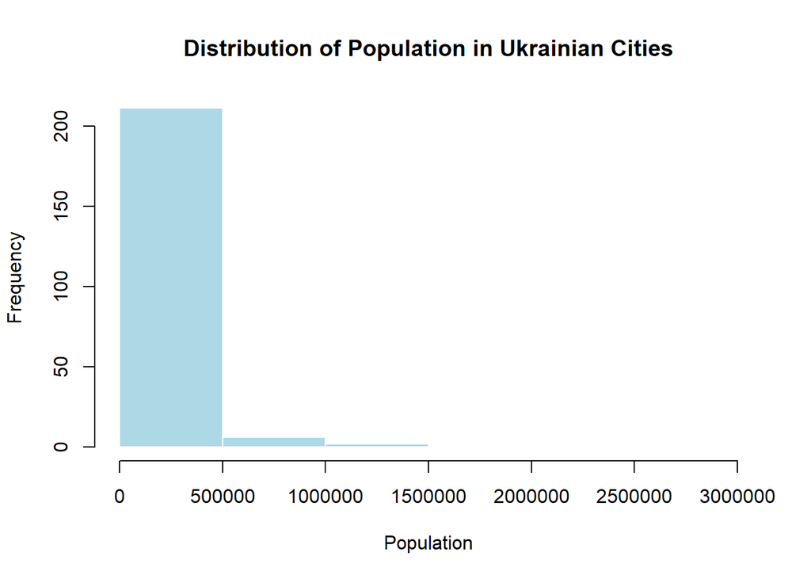

```r
library(dplyr)
library(ggplot2)
# Using dataset from Task 3
# data <- result of load_and_inspect("C:/Users/makuh/OneDrive/Desktop/ua.csv")

## 5.1 Quick Sketch (Base R Histogram)
# Numeric variable: population
hist(data$population,
     main = "Distribution of Population in Ukrainian Cities",
     xlab = "Population",
     col = "lightblue",
     border = "white")
```

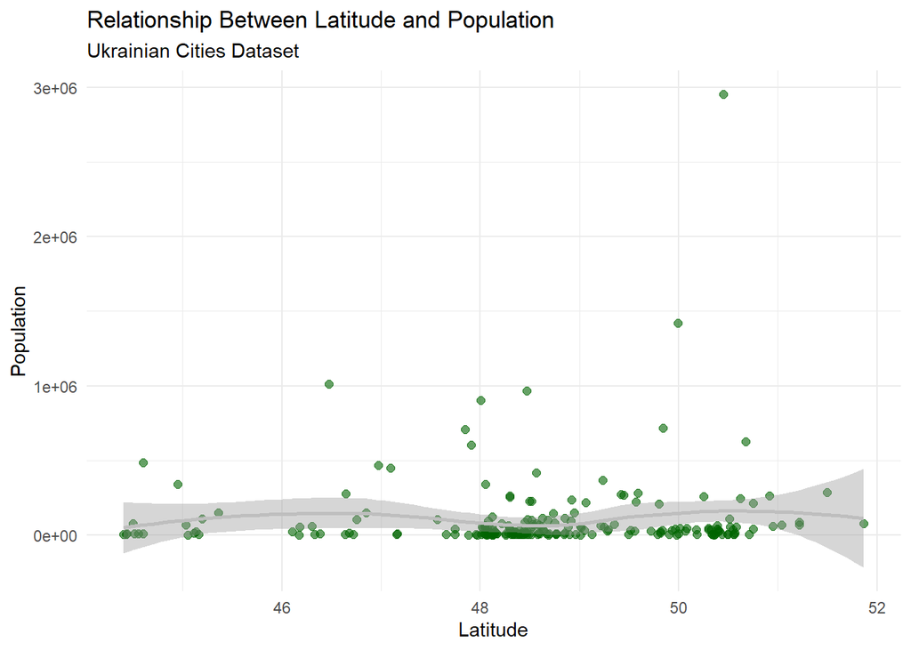

```r
## 5.2 Relationship Map (ggplot2 Scatter Plot)
# Numeric variables: lat and population
ggplot(data = data, aes(x = lat, y = population)) +
  geom_point(alpha = 0.6, size = 2, colour = "darkgreen") +
  geom_smooth(color = "gray") +
  labs(
    title = "Relationship Between Latitude and Population",
    subtitle = "Ukrainian Cities Dataset",
    x = "Latitude",
    y = "Population"
  ) +
  theme_minimal()
```

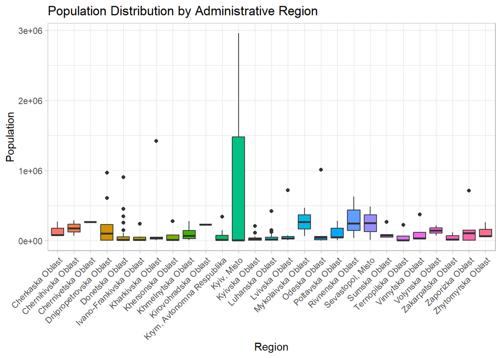

```r
## 5.3 Comparison (ggplot2 Boxplot)
# Categorical variable: admin_name, numeric variable: population
ggplot(data = data, aes(x = admin_name, y = population, fill = admin_name)) +
  geom_boxplot() +
  labs(
    title = "Population Distribution by Administrative Region",
    x = "Region",
    y = "Population"
  ) +
  theme_light() +
  theme(legend.position = "none") +
  theme(axis.text.x = element_text(angle = 45, hjust = 1))
```

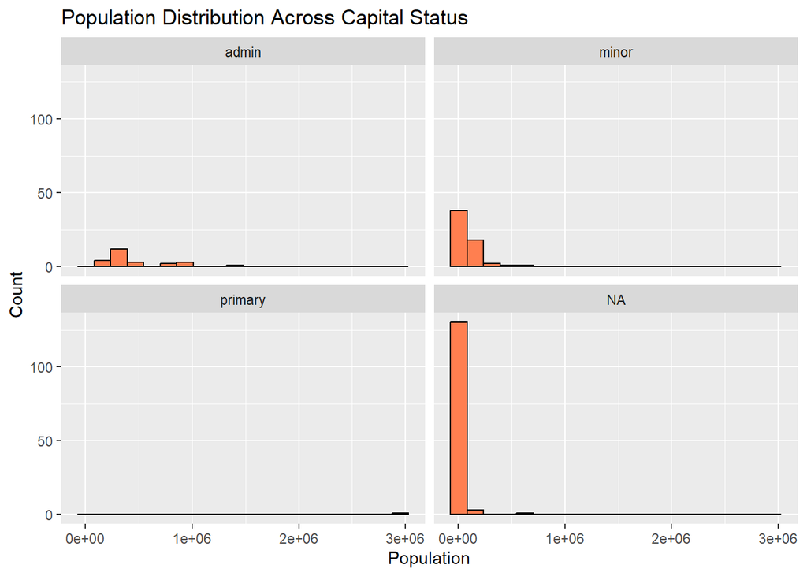

```r
## 5.4 Deep Dive (Faceting)
# Histogram of population faceted by capital status
ggplot(data = data, aes(x = population)) +
  geom_histogram(bins = 20, fill = "coral", color = "black") +
  facet_wrap(~ capital) +
  labs(
    title = "Population Distribution Across Capital Status",
    x = "Population",
    y = "Count"
  )
```

```r
## 5.5 Exporting a Plot
# Save the last plot (faceted histogram)
ggsave("ukraine_population_facet.png", width = 8, height = 6)
```